# Sequencing Results and Human Content Assessment

# Introduction

This notebook is to generate a variety of summary statistics for the sequencing results and human content of the libraries generated for this project.

# Infrastructure

Load tidyverse for data wrangling and plotting

```r
library(tidyverse)
library(ggbeeswarm)
library(scales)
library(patchwork)
```

Set project directory (if required!)

```r
proj_dir <- "/home/fellows/projects1/microbiome_calculus/evolution/"
```

Load files to be analysed

## Screening

```r
metadata_sample <- read_csv(paste0(proj_dir, "00-documentation.backup/01-calculus_microbiome_deep_evolution_samplescontrols_metadata_20200107.csv"))
metadata_individual <- read_tsv(paste0(proj_dir, "00-documentation.backup/02-calculus_microbiome-deep_evolution-individualscontrolssources_metadata_20190523.tsv"))
metadata_library_screening <- read_csv(paste0(proj_dir, "00-documentation.backup/03-human_filtering_statistics_20190522.csv"))
metadata_library_screening_polyg <- read_csv(paste0(proj_dir, "04-analysis/screening/eager/polyGremoval_output/output/Report_output.csv"))
```

## Deep

```r
metadata_library_deep <- read_csv(paste0(proj_dir, "03-preprocessing/deep/human_filtering/output/Report_output.csv"))
metadata_individual_deep <- read_tsv(paste0(proj_dir, "00-documentation.backup/17-Deep_Sequencing_HumanFiltering_Results_20190307.tsv"))
```

# Data Wranging

## Screening

Clean up poly G stats

```r
metadata_library_screening_polyg_clean <- metadata_library_screening_polyg %>%
  rename_all(function(x) str_replace(x, "^", "PolyG_")) %>%
  select(`PolyG_Sample Name`,
         `PolyG_# reads after C&M prior mapping`,
         `PolyG_# mapped reads prior RMDup`,
         `PolyG_Mapped Reads after RMDup`,
         `PolyG_# of reads on mitochondrium`
         ) %>%
  rename(Library_Name = `PolyG_Sample Name`,
         PolyG_Mapped_Reads = `PolyG_# mapped reads prior RMDup`,
         PolyG_Deduplicated_Mapped_Reads = `PolyG_Mapped Reads after RMDup`,
         PolyG_Deduplicated_mtDNA_Reads = `PolyG_# of reads on mitochondrium`
         )
```

Merging sample metadata and library preprocessing data.

> I am removing the single-stranded deeper sequenced samples here, as these are not used for compositional analysis, and only the amylase analysis

```r
metadata_combined_screening <- metadata_library_screening %>%
  rename(Library_Name = Sample_Name) %>%
  left_join(metadata_library_screening_polyg_clean) %>%
  mutate(Sample = map(Library_Name, function(x) str_extract(x, "^.{8}")[[1]] %>% head(n = 1)) %>% unlist,
         PolyG_Percent_Endogenous = (PolyG_Mapped_Reads / Post_Clip_and_Merge) * 100) %>%
  select(Sample, Library_Name, everything()) %>%
  left_join(metadata_sample) %>%
  filter(!is.na(Host_Common),
         !grepl(".SG.", Library_Name))
```

Summarise per Sample

```r
metadata_combined_screening_summary  <- metadata_combined_screening %>%
  select(Sample, Library_Name, Raw_Reads, Post_Clip_and_Merge, PolyG_Mapped_Reads, Percent_Endogenous_DNA, PolyG_Deduplicated_mtDNA_Reads, Group, Host_Common, PolyG_Percent_Endogenous) %>%
  mutate(Host_Common = factor(Host_Common, levels = c("Alouatta", "Gorilla", "Pan", "Homo (Neanderthal)", "Homo (Modern Human)"))) %>%
  group_by(Host_Common, Group, Sample) %>%
  summarise(Total_Raw_Reads = sum(Raw_Reads),
            Total_Processed_Reads = sum(Post_Clip_and_Merge),
            Total_Mapped_Reads = sum(PolyG_Mapped_Reads),
            Total_Deduplicated_mtDNA_Reads = sum(PolyG_Deduplicated_mtDNA_Reads),
            Mean_Percent_Endogenous = mean(Percent_Endogenous_DNA),
            Mean_PostPolyG_Percent_Endogenous = mean(PolyG_Percent_Endogenous)) %>%
  mutate(Total_AnalysisReadyReads = Total_Processed_Reads - Total_Mapped_Reads,
         Age = if_else(grepl("ModernDay", Group), "Modern", "Ancient"))
```

> Note: Total_Mapped_Reads appears to be reported incorrectly. The DeDup log reports a number which when removing this from input mapped reads does not result in the number contained in the output BAM file itself. We will ignore this.

## Deep

Clean up mapping

```r
metadata_library_deep_clean <- metadata_library_deep %>%
  mutate(Individual = map(`Sample Name`, function(x) str_extract(x, "^.{6}")[[1]]) %>% unlist) %>%
  separate(`Sample Name`, c("Sample", "Lane"), sep = "_") %>%
  mutate(Lane = if_else(is.na(Lane), "L1", Lane)) %>%
  select(Individual, Sample, Lane, everything(), -`Sample number`) %>%
  group_by(Individual, Sample) %>%
  summarise(Library_Raw_Reads = sum(`# of Raw Reads prior Clip & Merge (C&M)`),
            Library_Processed_Reads = sum(`# reads after C&M prior mapping`),
            Library_Mapped_Reads = sum(`# mapped reads prior RMDup`),
            Percent_Endogenous_DNA = mean(`Endogenous DNA (%)`),
            mtDNA_Reads = sum(`# of reads on mitochondrium`)) %>%
  filter(!grepl("LIB", Individual))
```

```
Expected 2 pieces. Missing pieces filled with `NA` in 19 rows [19, 20, 21, 22, 23, 24, 25, 26, 27, 28, 29, 30, 31, 32, 33, 34, 44, 45, 46].
```

Summarise per Individual

```r
metadata_library_deep_summary <- metadata_library_deep_clean %>%
  group_by(Individual) %>%
  summarise(Total_Raw_Reads = sum(Library_Raw_Reads),
            Total_Processed_Reads = sum(Library_Processed_Reads),
            Total_Mapped_Reads = sum(Library_Mapped_Reads),
            Total_mtDNA_Reads = sum(mtDNA_Reads),
            Mean_Percent_Endogenous = mean(Percent_Endogenous_DNA))
```

Add remaining metadata

```r
metadata_combined_deep <- metadata_library_deep_summary %>%
  left_join(metadata_individual_deep, by = c("Individual" = "sample_name")) %>%
  mutate(Total_AnalysisReadyReads = Total_Processed_Reads - Total_Mapped_Reads,
         Age = if_else(grepl("ModernDay", Host_Common), "Modern", "Ancient"),
         Host_Common = factor(Host_Common, levels = c("Alouatta", "Gorilla",
                                                      "Pan",
                                                      "Homo (Neanderthal)",
                                                      "Homo (Modern Human)")))
```

# Data Summary

## Screening

### Per Dataset

Set general function

```r
summarise_multiple <- function(x, group_col){
  group_col <- enquo(group_col)
  paste(group_col)
  x %>%
    group_by(!! group_col) %>%
    summarise_if(is.numeric, list(Mean = mean, SD = sd, Min = min, Max = max, Sum = sum)) %>%
    gather(Metric, Value, 2:ncol(.)) %>%
    mutate(Summary = map(Metric, function(x) str_split(x, "_")[[1]] %>% tail(n = 1)) %>% unlist,
           Metric = map(Metric, function(x) {
             name <- str_split(x, "_")[[1]]
             len <- length(name)
             return(name %>% head(n = (len - 1)) %>% paste(collapse = "_"))}
             ) %>% unlist,
           Value = as.numeric(Value) %>% round(2)) %>%
    spread(Summary, Value) %>%
    select(!! group_col, Metric, Mean, SD, Min, Max, Sum)
}
```

Across entire data

```r
metadata_combined_screening_summary %>%
  summarise_multiple(., Age)
```

```
Using `as.character()` on a quosure is deprecated as of rlang 0.3.0.
Please use `as_label()` or `as_name()` instead.
```

| Age | Metric | Mean | SD | Min | Max | Sum |
| --- | --- | --- | --- | --- | --- | --- |
| Ancient | Mean_Percent_Endogenous | 5.92 | 14.15 | 0.16 | 85.83 | 6.337800e+02 |
| Ancient | Mean_PostPolyG_Percent_Endogenous | 7.16 | 19.91 | 0.03 | 143.02 | 7.665400e+02 |
| Ancient | Total_AnalysisReadyReads | 10693662.71 | 5618691.34 | -2994513.00 | 33830826.00 | 1.144222e+09 |
| Ancient | Total_Deduplicated_mtDNA_Reads | 755.63 | 3536.08 | 0.00 | 29306.00 | 8.085200e+04 |
| Ancient | Total_Mapped_Reads | 762919.08 | 2102334.00 | 3302.00 | 14861197.00 | 8.163234e+07 |
| Ancient | Total_Processed_Reads | 11456581.79 | 5392131.50 | 71296.00 | 36597397.00 | 1.225854e+09 |
| Ancient | Total_Raw_Reads | 24049205.34 | 11898575.88 | 127330.00 | 58161058.00 | 2.573265e+09 |
| Modern | Mean_Percent_Endogenous | 1.59 | 3.98 | 0.32 | 17.41 | 2.857000e+01 |
| Modern | Mean_PostPolyG_Percent_Endogenous | 2.20 | 6.87 | 0.03 | 29.57 | 3.952000e+01 |
| Modern | Total_AnalysisReadyReads | 50877437.83 | 22526819.51 | 15763027.00 | 94719628.00 | 9.157939e+08 |

[output cut: 4 more lines]

Per host (using common names)

```r
metadata_combined_screening_summary %>%
  filter(Age == "Ancient") %>%
  summarise_multiple(., Host_Common)
```

| Host_Common | Metric | Mean | SD | Min | Max | Sum |
| --- | --- | --- | --- | --- | --- | --- |
| Alouatta | Mean_Percent_Endogenous | 0.90 | 0.19 | 0.65 | 1.16 | 4.520000e+00 |
| Alouatta | Mean_PostPolyG_Percent_Endogenous | 1.25 | 0.32 | 0.83 | 1.71 | 6.240000e+00 |
| Alouatta | Total_AnalysisReadyReads | 11227124.40 | 2846819.07 | 7391624.00 | 13925046.00 | 5.613562e+07 |
| Alouatta | Total_Deduplicated_mtDNA_Reads | 7.20 | 4.82 | 2.00 | 13.00 | 3.600000e+01 |
| Alouatta | Total_Mapped_Reads | 145631.20 | 65340.62 | 78886.00 | 242773.00 | 7.281560e+05 |
| Alouatta | Total_Processed_Reads | 11372755.60 | 2903093.89 | 7487708.00 | 14159411.00 | 5.686378e+07 |
| Alouatta | Total_Raw_Reads | 21267576.80 | 6009981.25 | 13515446.00 | 27514202.00 | 1.063379e+08 |
| Gorilla | Mean_Percent_Endogenous | 6.04 | 10.40 | 0.55 | 43.70 | 1.751800e+02 |
| Gorilla | Mean_PostPolyG_Percent_Endogenous | 8.61 | 14.53 | 0.15 | 57.55 | 2.498300e+02 |
| Gorilla | Total_AnalysisReadyReads | 9973817.93 | 7069076.20 | 2373962.00 | 33830826.00 | 2.892407e+08 |

[output cut: 25 more lines]

```r
metadata_combined_screening_summary %>%
  filter(Age == "Modern") %>%
  summarise_multiple(., Host_Common)
```

| Host_Common | Metric | Mean | SD | Min | Max | Sum |
| --- | --- | --- | --- | --- | --- | --- |
| Homo (Modern Human) | Mean_Percent_Endogenous | 1.59 | 3.98 | 0.32 | 17.41 | 2.857000e+01 |
| Homo (Modern Human) | Mean_PostPolyG_Percent_Endogenous | 2.20 | 6.87 | 0.03 | 29.57 | 3.952000e+01 |
| Homo (Modern Human) | Total_AnalysisReadyReads | 50877437.83 | 22526819.51 | 15763027.00 | 94719628.00 | 9.157939e+08 |
| Homo (Modern Human) | Total_Deduplicated_mtDNA_Reads | 542.89 | 843.09 | 9.00 | 3476.00 | 9.772000e+03 |
| Homo (Modern Human) | Total_Mapped_Reads | 997350.00 | 2864540.92 | 11145.00 | 12336074.00 | 1.795230e+07 |
| Homo (Modern Human) | Total_Processed_Reads | 51874787.83 | 22204081.90 | 15783566.00 | 94897020.00 | 9.337462e+08 |
| Homo (Modern Human) | Total_Raw_Reads | 88251982.22 | 31090218.72 | 31782890.00 | 148237418.00 | 1.588536e+09 |

```r
NA
```

For inividual counts

```r
## all ancient
metadata_sample  %>%
  filter(!grepl("VLC|JAE", Sample)) %>%
  group_by(Host_Common) %>%
  summarise(N = n())
```

| Host_Common | N |
| --- | --- |
| Alouatta | 5 |
| EnvironmentalControl | 10 |
| ExtractionControl | 19 |
| Gorilla | 29 |
| Homo (Modern Human) | 40 |
| Homo (Neanderthal) | 14 |
| LibraryControl | 21 |
| Pan | 20 |

```r
## only modern day individuals
metadata_sample  %>%
  filter(grepl("VLC|JAE", Sample)) %>%
  group_by(Host_Common) %>%
  summarise(N = n())
```

| Host_Common | N |
| --- | --- |
| Homo (Modern Human) | 18 |

> Note that there are two ‘samples’ for GDN although that is technically wrong.

For blanks, we can do the following

```r
metadata_library_screening %>%
  rename(Library_Name = Sample_Name) %>%
  left_join(metadata_library_screening_polyg_clean) %>%
  left_join(metadata_sample, by = c("Library_Name" = "Sample")) %>%
  mutate(PolyG_Percent_Endogenous = (PolyG_Mapped_Reads / Post_Clip_and_Merge) * 100) %>%
  filter(grepl("EXB|LIB", Library_Name)) %>%
  group_by(Group) %>%
  summarise_at(vars(Raw_Reads, Post_Clip_and_Merge, Percent_Endogenous_DNA, PolyG_Percent_Endogenous), list(Mean = mean, SD = sd, Min = min, Max = max)) %>%
  gather(Metric, Value, 2:ncol(.)) %>%
  arrange(Group, Metric) %>%
  mutate(Value = round(Value, 2))
```

| Group | Metric | Value |
| --- | --- | --- |
| ExtractionBlank | Percent_Endogenous_DNA_Max | 38.97 |
| ExtractionBlank | Percent_Endogenous_DNA_Mean | 18.86 |
| ExtractionBlank | Percent_Endogenous_DNA_Min | 0.99 |
| ExtractionBlank | Percent_Endogenous_DNA_SD | 16.09 |
| ExtractionBlank | PolyG_Percent_Endogenous_Max | 13.17 |
| ExtractionBlank | PolyG_Percent_Endogenous_Mean | 3.38 |
| ExtractionBlank | PolyG_Percent_Endogenous_Min | 0.90 |
| ExtractionBlank | PolyG_Percent_Endogenous_SD | 3.26 |
| ExtractionBlank | Post_Clip_and_Merge_Max | 2445235.00 |
| ExtractionBlank | Post_Clip_and_Merge_Mean | 891136.00 |

[output cut: 22 more lines]

> Note that EXB0{20..23}.A0102 actually is a resequencing of the A0101 versions because the former failed.

### Per Individual

[output not shown]

[output cut: 823 more lines]

## Deep

Across whole dataset

```r
metadata_combined_deep %>%
  summarise_multiple(., Age) %>%
  filter(Metric %in% c("Total_Raw_Reads",
                       "Total_Processed_Reads",
                       "Total_AnalysisReadyReads"))
```

| Age | Metric | Mean | SD | Min | Max | Sum |
| --- | --- | --- | --- | --- | --- | --- |
| Ancient | Total_AnalysisReadyReads | 103123982 | 79795307 | 23060600 | 326113634 | 1959355663 |
| Ancient | Total_Processed_Reads | 104159324 | 81055104 | 23327553 | 332990717 | 1979027160 |
| Ancient | Total_Raw_Reads | 203949553 | 123359872 | 61703682 | 479828768 | 3875041498 |

Per host common

```r
metadata_combined_deep %>%
  summarise_multiple(., Host_Common) %>%
  filter(Metric %in% c("Total_AnalysisReadyReads",
                       "total_number_raw_reads_before_clipmerge",
                       "Total_AnalysisReadyReads"))
```

| Host_Common | Metric | Mean | SD | Min | Max | Sum |
| --- | --- | --- | --- | --- | --- | --- |
| Alouatta | Total_AnalysisReadyReads | 110247421 | 50136787 | 72108557 | 167036446 | 330742263 |
| Alouatta | total_number_raw_reads_before_clipmerge | 202700902 | 81904503 | 145490044 | 296525468 | 608102706 |
| Gorilla | Total_AnalysisReadyReads | 88927251 | 59587055 | 51793321 | 157658153 | 266781752 |
| Gorilla | total_number_raw_reads_before_clipmerge | 229537513 | 130722499 | 145419258 | 380139080 | 688612538 |
| Pan | Total_AnalysisReadyReads | 155248637 | 72527567 | 89247751 | 257257164 | 620994549 |
| Pan | total_number_raw_reads_before_clipmerge | 277405473 | 158159041 | 102180635 | 479828768 | 1109621893 |
| Homo (Neanderthal) | Total_AnalysisReadyReads | 133092916 | 167706862 | 23060600 | 326113634 | 399278748 |
| Homo (Neanderthal) | total_number_raw_reads_before_clipmerge | 201527834 | 210113570 | 61703682 | 443150763 | 604583501 |
| Homo (Modern Human) | Total_AnalysisReadyReads | 56926392 | 25792155 | 26733630 | 99161900 | 341558351 |
| Homo (Modern Human) | total_number_raw_reads_before_clipmerge | 144020143 | 59778490 | 65053436 | 219760056 | 864120860 |

Individual counts

```r
metadata_combined_deep %>%
  group_by(Host_Common) %>%
  summarise(N = n())
```

| Host_Common | N |
| --- | --- |
| Alouatta | 3 |
| Gorilla | 3 |
| Pan | 4 |
| Homo (Neanderthal) | 3 |
| Homo (Modern Human) | 6 |

For controls

```r
metadata_library_deep %>%
  mutate(Individual = map(`Sample Name`, function(x) str_extract(x, "^.{6}")[[1]]) %>% unlist) %>%
  separate(`Sample Name`, c("Sample", "Lane"), sep = "_") %>%
  mutate(Lane = if_else(is.na(Lane), "L1", Lane)) %>%
  select(Individual, Sample, Lane, everything(), -`Sample number`) %>%
  group_by(Individual, Sample) %>%
  summarise(Library_Raw_Reads = sum(`# of Raw Reads prior Clip & Merge (C&M)`),
            Library_Processed_Reads = sum(`# reads after C&M prior mapping`),
            Library_Mapped_Reads = sum(`# mapped reads prior RMDup`),
            Percent_Endogenous_DNA = mean(`Endogenous DNA (%)`),
            mtDNA_Reads = sum(`# of reads on mitochondrium`)) %>%
  filter(grepl("LIB", Individual)) %>%
  arrange(Library_Processed_Reads) %>%
  ungroup() %>%
  summarise_at(vars(Library_Raw_Reads,Library_Processed_Reads, Percent_Endogenous_DNA), list(Mean = mean, SD = sd, Min = min, Max = max)) %>%
  gather(Metric, Value, 1:ncol(.)) %>%
  arrange(Metric) %>%
  mutate(Value = round(Value, 2))
```

```
Expected 2 pieces. Missing pieces filled with `NA` in 19 rows [19, 20, 21, 22, 23, 24, 25, 26, 27, 28, 29, 30, 31, 32, 33, 34, 44, 45, 46].
```

| Metric | Value |
| --- | --- |
| Library_Processed_Reads_Max | 1377612.00 |
| Library_Processed_Reads_Mean | 685794.33 |
| Library_Processed_Reads_Min | 251819.00 |
| Library_Processed_Reads_SD | 403933.34 |
| Library_Raw_Reads_Max | 2830970.00 |
| Library_Raw_Reads_Mean | 2011820.67 |
| Library_Raw_Reads_Min | 1227864.00 |
| Library_Raw_Reads_SD | 700785.88 |
| Percent_Endogenous_DNA_Max | 42.37 |
| Percent_Endogenous_DNA_Mean | 28.93 |

[output cut: 2 more lines]

# Data Visualisation

## Screening

Raw Reads (per library!) i.e. sequencing depth

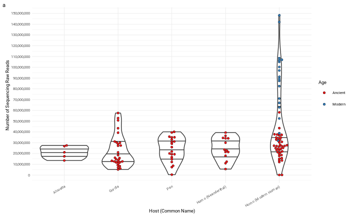

```r
plot_screening_rawreads <- ggplot(metadata_combined_screening_summary, aes(Host_Common, Total_Raw_Reads)) +
  geom_violin(draw_quantiles = c(0.25, 0.5, 0.75)) +
  geom_beeswarm(aes(fill = Age), colour = "black", shape = 21, stroke = 0.2) +
  scale_fill_brewer(palette = "Set1") +
  xlab("Host (Common Name)") +
  ylab("Number of Sequencing Raw Reads") +
  labs(tag = "a") +
  scale_y_continuous(breaks = seq(0,
                                  150000000,
                                  10000000),
                     labels = comma) +
  theme_minimal(base_size = 7, base_family = "Roboto") +
  theme(axis.text.x = element_text(angle = 30, hjust = 1))


plot_screening_rawreads
```

Processed Reads (per library!) i.e. post-adapter removal

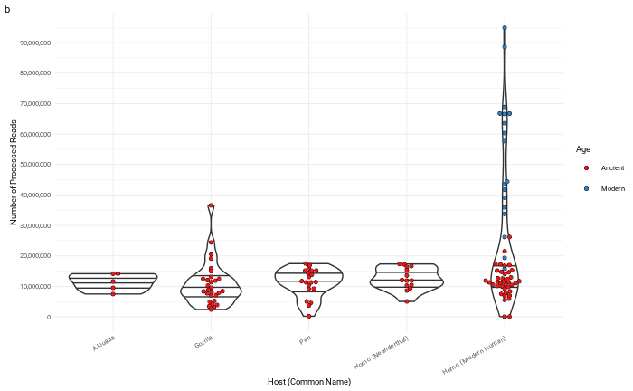

```r
plot_screening_totalprocessedreads <- ggplot(metadata_combined_screening_summary, aes(Host_Common, Total_Processed_Reads)) +
  geom_violin(draw_quantiles = c(0.25, 0.5, 0.75)) +
  geom_beeswarm(aes(fill = Age), colour = "black", shape = 21, stroke = 0.2) +
  xlab("Host (Common Name)") +
  ylab("Number of Processed Reads") +
  labs(tag = "b") +
  scale_fill_brewer(palette = "Set1") +
  scale_y_continuous(breaks = seq(0,
                                  150000000,
                                  10000000),
                     labels = comma) +
  theme_minimal(base_size = 7, base_family = "Roboto") +
  theme(axis.text.x = element_text(angle = 30, hjust = 1))


plot_screening_totalprocessedreads
```

Mean Percent Endogenous (per library!)

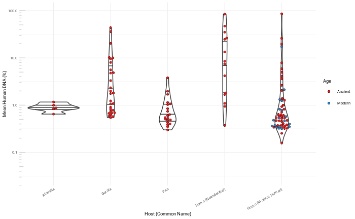

```r
ggplot(metadata_combined_screening_summary, aes(Host_Common, Mean_Percent_Endogenous)) +
  geom_violin(draw_quantiles = c(0.25, 0.5, 0.75)) +
  geom_beeswarm(aes(fill = Age), colour = "black", shape = 21, stroke = 0.2) +
  scale_fill_brewer(palette = "Set1") +
  scale_y_log10(limits = c(0.03, 100)) +
  xlab("Host (Common Name)") +
  ylab("Mean Human DNA (%)") +
  annotation_logticks(sides = "l", scaled = T, colour = "lightgrey") +
  theme_minimal(base_size = 7, base_family = "Roboto") +
  theme(axis.text.x = element_text(angle = 30, hjust = 1))
```

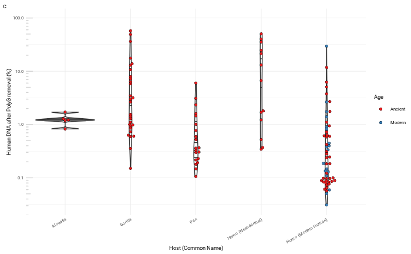

```r
plot_screening_postpolyGhumancontent <- ggplot(metadata_combined_screening_summary, aes(Host_Common, Mean_PostPolyG_Percent_Endogenous)) +
  geom_violin(draw_quantiles = c(0.25, 0.5, 0.75)) +
  geom_beeswarm(aes(fill = Age), colour = "black", shape = 21, stroke = 0.2) +
  scale_fill_brewer(palette = "Set1") +
  xlab("Host (Common Name)") +
  ylab("Human DNA after PolyG removal (%)") +
  labs(tag = "c") +
  scale_y_log10(limits = c(0.03, 100)) +
  annotation_logticks(sides = "l", scaled = T, colour = "lightgrey") +
  theme_minimal(base_size = 7, base_family = "Roboto") +
  theme(axis.text.x = element_text(angle = 30, hjust = 1))


plot_screening_postpolyGhumancontent
```

mtDNA Mapped Reads (per library!)

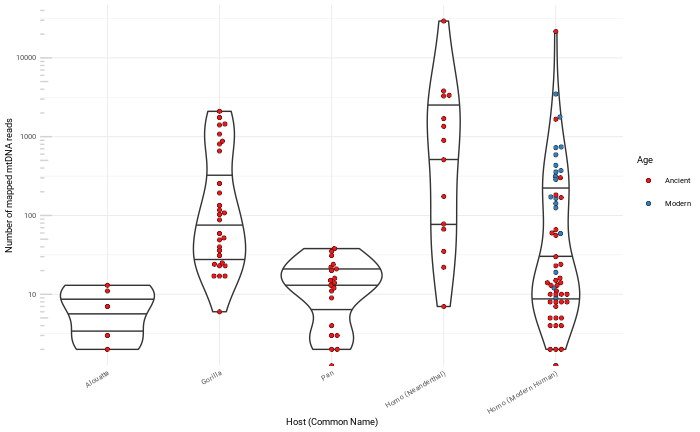

```r
ggplot(metadata_combined_screening_summary, aes(Host_Common, Total_Deduplicated_mtDNA_Reads)) +
  geom_violin(draw_quantiles = c(0.25, 0.5, 0.75)) +
  geom_beeswarm(aes(fill = Age), colour = "black", shape = 21, stroke = 0.2) +
  scale_fill_brewer(palette = "Set1") +
  xlab("Host (Common Name)") +
  ylab("Number of mapped mtDNA reads") +
  scale_y_log10() +
  annotation_logticks(sides = "l", scaled = T, colour = "lightgrey") +
  theme_minimal(base_size = 7, base_family = "Roboto") +
  theme(axis.text.x = element_text(angle = 30, hjust = 1))
```

```r
NA
```

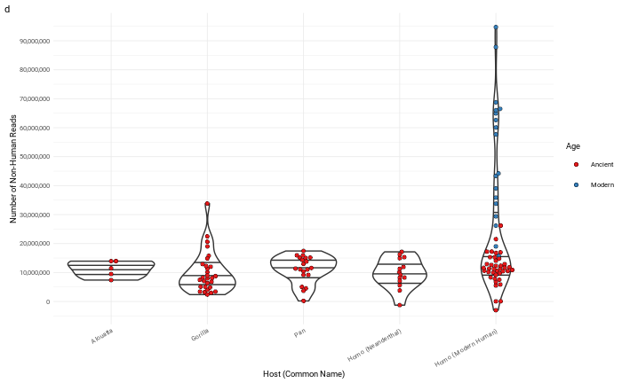

```r
plot_screening_totalnonhumanreads <- ggplot(metadata_combined_screening_summary,
                                             aes(Host_Common, Total_AnalysisReadyReads)) +
  geom_violin(draw_quantiles = c(0.25, 0.5, 0.75)) +
  geom_beeswarm(aes(fill = Age), colour = "black", shape = 21, stroke = 0.2) +
  xlab("Host (Common Name)") +
  ylab("Number of Non-Human Reads") +
  labs(tag = "d") +
  scale_fill_brewer(palette = "Set1") +
  scale_y_continuous(breaks = seq(0,
                                  150000000,
                                  10000000),
                     labels = comma) +
  theme_minimal(base_size = 7, base_family = "Roboto") +
  theme(axis.text.x = element_text(angle = 30, hjust = 1))


plot_screening_totalnonhumanreads
```

```r
NA
```

To put together figure for supplementary text

```r
final_screening_plot <- plot_screening_rawreads +
  plot_screening_totalprocessedreads +
  plot_screening_postpolyGhumancontent +
  plot_screening_totalnonhumanreads +
  plot_layout(ncol = 2)

ggsave(paste0("SupFigX_SequencingQCSummaries_NewCalculusOnly_Screening_AncientModern_" ,
             format(Sys.Date(), "%Y%m%d"),".pdf"),
       plot = final_screening_plot,
       device = cairo_pdf,
       width = 7,
       height = 5,
       units = "in",
       dpi = 600)

ggsave(paste0("SupFigX_SequencingQCSummaries_NewCalculusOnly_Screening_AncientModern_" ,
             format(Sys.Date(), "%Y%m%d"),".png"),
       plot = final_screening_plot,
       device = "png",
       width = 7,
       height = 5,
       units = "in",
       dpi = 300)
```

## Deep

Total sequenced reads per sample

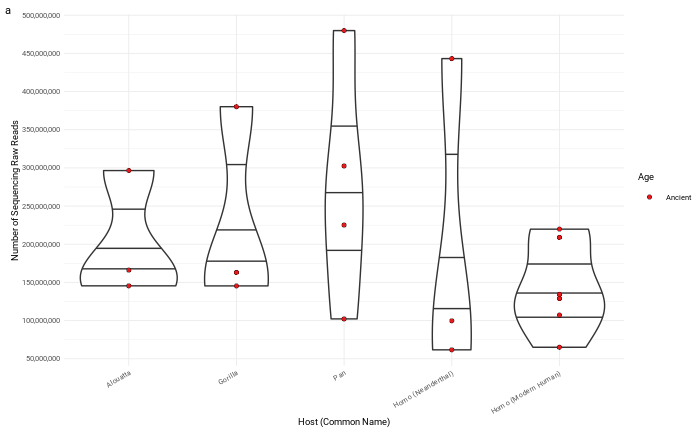

```r
plot_deep_rawreads <- ggplot(metadata_combined_deep, aes(Host_Common, Total_Raw_Reads)) +
  geom_violin(draw_quantiles = c(0.25, 0.5, 0.75)) +
  geom_beeswarm(aes(fill = Age), colour = "black", shape = 21, stroke = 0.2) +
  scale_fill_brewer(palette = "Set1") +
  xlab("Host (Common Name)") +
  ylab("Number of Sequencing Raw Reads") +
  labs(tag = "a") +
  scale_y_continuous(breaks = seq(0,
                                  500000000,
                                  50000000),
                     labels = comma) +
  theme_minimal(base_size = 7, base_family = "Roboto") +
  theme(axis.text.x = element_text(angle = 30, hjust = 1))


plot_deep_rawreads
```

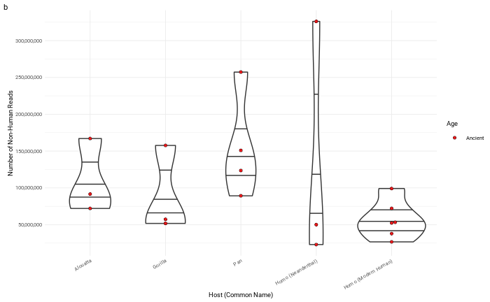

```r
plot_deep_totalnonhumanreads <- ggplot(metadata_combined_deep,
                                             aes(Host_Common, Total_AnalysisReadyReads)) +
  geom_violin(draw_quantiles = c(0.25, 0.5, 0.75)) +
  geom_beeswarm(aes(fill = Age), colour = "black", shape = 21, stroke = 0.2) +
  xlab("Host (Common Name)") +
  ylab("Number of Non-Human Reads") +
  labs(tag = "b") +
  scale_fill_brewer(palette = "Set1") +
  scale_y_continuous(breaks = seq(0,
                                  500000000,
                                  50000000),
                     labels = comma) +
  theme_minimal(base_size = 7, base_family = "Roboto") +
  theme(axis.text.x = element_text(angle = 30, hjust = 1))


plot_deep_totalnonhumanreads
```

And save

```r
final_deep_plot <- plot_deep_rawreads +
  plot_deep_totalnonhumanreads +
  plot_layout(ncol = 2)

final_deep_plot

ggsave(paste0("SupFigX_SequencingQCSummaries_NewCalculusOnly_Deep_AncientOnly_" ,
             format(Sys.Date(), "%Y%m%d"),".pdf"),
       plot = final_deep_plot,
       device = cairo_pdf,
       width = 7,
       height = 2.5,
       units = "in",
       dpi = 600)
```

[figure not shown]

```r
ggsave(paste0("SupFigX_SequencingQCSummaries_NewCalculusOnly_Deep_AncientOnly_" ,
             format(Sys.Date(), "%Y%m%d"),".png"),
       plot = final_deep_plot,
       device = "png",
       width = 7,
       height = 2.5,
       units = "in",
       dpi = 300)
```